# IODS course project

# About the project

*Write a short description about the course and add a link to your github repository here. This is an R markdown (.Rmd) file so you can use R markdown syntax. See the ‘Useful links’ page in the mooc area (chapter 1) for instructions.*

the course is about openly sharing data and code to achieve a certain goal or complete a project. link to my github repository https://github.com/qiuyufan/IODS-project.git

Analysis

#### 1.read the data to R

```r
joined_data <- read.csv(file="alc.csv", header=TRUE)
colnames(joined_data)
```

```
##  [1] "school"     "sex"        "age"        "address"    "famsize"
##  [6] "Pstatus"    "Medu"       "Fedu"       "Mjob"       "Fjob"
## [11] "reason"     "nursery"    "internet"   "guardian"   "traveltime"
## [16] "studytime"  "failures"   "schoolsup"  "famsup"     "paid"
## [21] "activities" "higher"     "romantic"   "famrel"     "freetime"
## [26] "goout"      "Dalc"       "Walc"       "health"     "absences"
## [31] "G1"         "G2"         "G3"         "alc_use"    "high_use"
```

```r
summary(joined_data)
```

```
##  school   sex          age        address famsize   Pstatus
##  GP:342   F:198   Min.   :15.00   R: 81   GT3:278   A: 38
##  MS: 40   M:184   1st Qu.:16.00   U:301   LE3:104   T:344
##                   Median :17.00
##                   Mean   :16.59
##                   3rd Qu.:17.00
##                   Max.   :22.00
##       Medu            Fedu             Mjob           Fjob
##  Min.   :0.000   Min.   :0.000   at_home : 53   at_home : 16
##  1st Qu.:2.000   1st Qu.:2.000   health  : 33   health  : 17
##  Median :3.000   Median :3.000   other   :138   other   :211
##  Mean   :2.806   Mean   :2.565   services: 96   services:107
##  3rd Qu.:4.000   3rd Qu.:4.000   teacher : 62   teacher : 31
##  Max.   :4.000   Max.   :4.000
##         reason    nursery   internet    guardian     traveltime
##  course    :140   no : 72   no : 58   father: 91   Min.   :1.000
##  home      :110   yes:310   yes:324   mother:275   1st Qu.:1.000
##  other     : 34                       other : 16   Median :1.000
##  reputation: 98                                    Mean   :1.448
##                                                    3rd Qu.:2.000
##                                                    Max.   :4.000
##    studytime        failures      schoolsup famsup     paid     activities
##  Min.   :1.000   Min.   :0.0000   no :331   no :144   no :205   no :181
##  1st Qu.:1.000   1st Qu.:0.0000   yes: 51   yes:238   yes:177   yes:201
##  Median :2.000   Median :0.0000
##  Mean   :2.037   Mean   :0.2016
##  3rd Qu.:2.000   3rd Qu.:0.0000
##  Max.   :4.000   Max.   :3.0000
##  higher    romantic      famrel         freetime        goout
##  no : 18   no :261   Min.   :1.000   Min.   :1.00   Min.   :1.000
##  yes:364   yes:121   1st Qu.:4.000   1st Qu.:3.00   1st Qu.:2.000
##                      Median :4.000   Median :3.00   Median :3.000
##                      Mean   :3.937   Mean   :3.22   Mean   :3.113
##                      3rd Qu.:5.000   3rd Qu.:4.00   3rd Qu.:4.000
##                      Max.   :5.000   Max.   :5.00   Max.   :5.000
##       Dalc            Walc           health         absences
##  Min.   :1.000   Min.   :1.000   Min.   :1.000   Min.   : 0.0
##  1st Qu.:1.000   1st Qu.:1.000   1st Qu.:3.000   1st Qu.: 1.0
##  Median :1.000   Median :2.000   Median :4.000   Median : 3.0
##  Mean   :1.482   Mean   :2.296   Mean   :3.573   Mean   : 4.5
##  3rd Qu.:2.000   3rd Qu.:3.000   3rd Qu.:5.000   3rd Qu.: 6.0
##  Max.   :5.000   Max.   :5.000   Max.   :5.000   Max.   :45.0
##        G1              G2              G3           alc_use
##  Min.   : 2.00   Min.   : 4.00   Min.   : 0.00   Min.   :1.000
##  1st Qu.:10.00   1st Qu.:10.00   1st Qu.:10.00   1st Qu.:1.000
##  Median :12.00   Median :12.00   Median :12.00   Median :1.500
##  Mean   :11.49   Mean   :11.47   Mean   :11.46   Mean   :1.889
##  3rd Qu.:14.00   3rd Qu.:14.00   3rd Qu.:14.00   3rd Qu.:2.500
##  Max.   :18.00   Max.   :18.00   Max.   :18.00   Max.   :5.000
##   high_use
##  Mode :logical
##  FALSE:268
##  TRUE :114
##
##
##
```

The data is combined by both student-mat.csv (Math course) and student-por.csv (Portuguese language course) datasets. The data attributes include student grades, demographic, social and school related features) and it was collected by using school reports and questionnaires.

#### 2.Choose 4 interesting variables with alcohol consumption

“sex”, “guardian”,“freetime”,“paid” “sex”: male would have high alcohol consumption, while female have low alcohol consumption “guardian”:as father would have high consumption, with mother have low consumption “freetime”: more free time, high consumption “paid”: more paid, more consumption

#### 3.explore the distributions of the chosen variables and their relationships with alcohol consumption

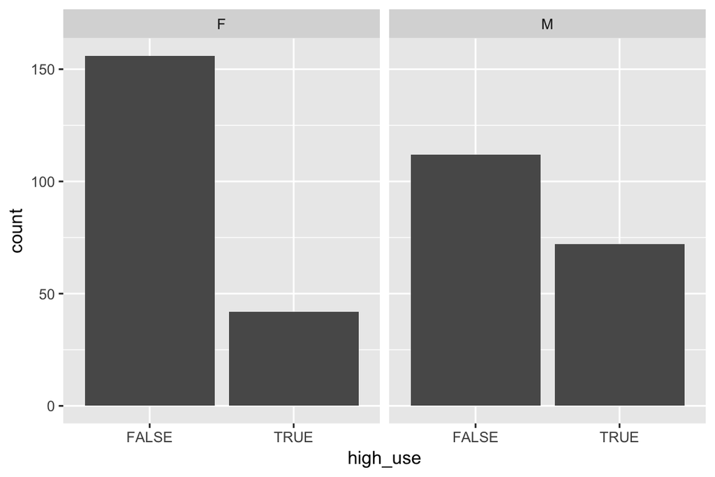

```r
library(ggplot2)
library(dplyr)
g2 <- ggplot(joined_data, aes(high_use))
g2 + facet_wrap("sex") + geom_bar()
```

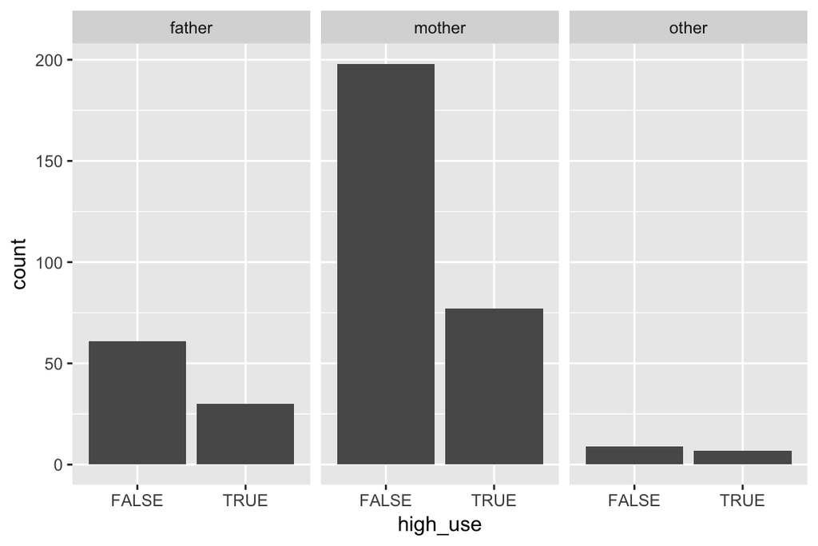

```r
g2 + facet_wrap("guardian") + geom_bar()
```

Plot2 shows that being with mother has less high use alcohol percentage than being with father.

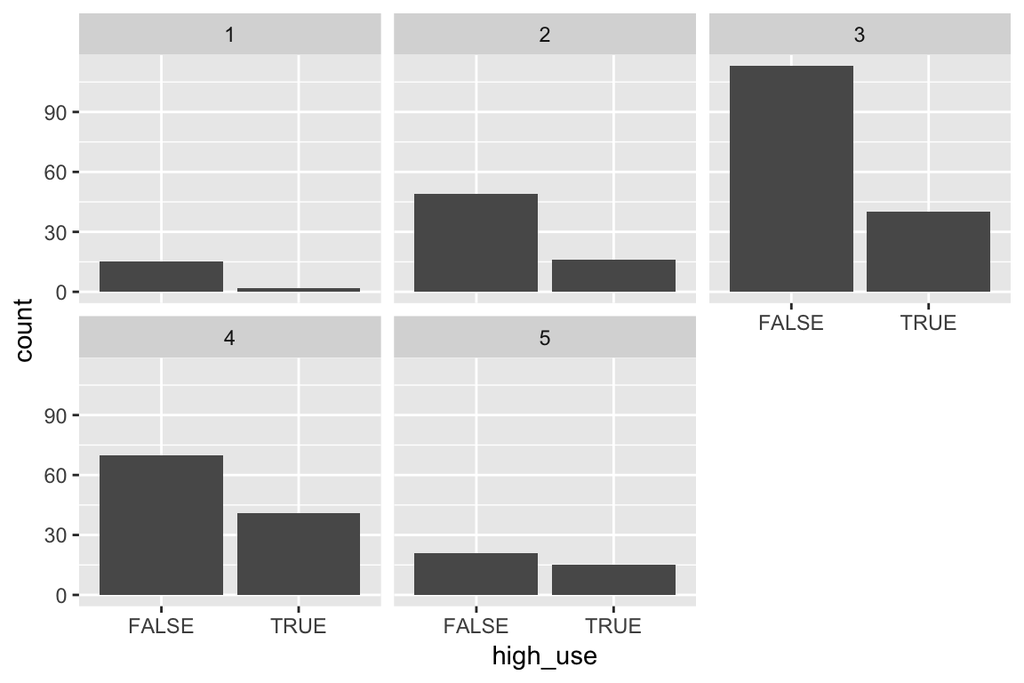

```r
g2 + facet_wrap("freetime") + geom_bar()
```

Plot3 shows that students who enjoy most free time also enjoy the high use alcohol. It seems to be linearly correlated.

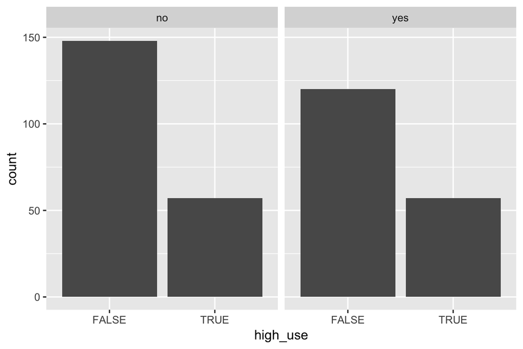

```r
g2 + facet_wrap("paid") + geom_bar()
```

Plot4 shows that students who got paid have a slightly higher high use of alcohol consumption.

#### 4.Using logistic regression to explore the data

```r
m <- glm(high_use ~ freetime + paid + sex + guardian , data = joined_data, family = "binomial")
summary(m)
```

```
##
## Call:
## glm(formula = high_use ~ freetime + paid + sex + guardian, family = "binomial",
##     data = joined_data)
##
## Deviance Residuals:
##     Min       1Q   Median       3Q      Max
## -1.3508  -0.8560  -0.6722   1.2416   2.0250
##
## Coefficients:
##                Estimate Std. Error z value Pr(>|z|)
## (Intercept)     -2.2203     0.4881  -4.549  5.4e-06 ***
## freetime         0.2701     0.1225   2.206 0.027387 *
## paidyes          0.3954     0.2356   1.678 0.093323 .
## sexM             0.8272     0.2400   3.446 0.000568 ***
## guardianmother  -0.2326     0.2696  -0.863 0.388217
## guardianother    0.4411     0.5705   0.773 0.439404
## ---
## Signif. codes:  0 '***' 0.001 '**' 0.01 '*' 0.05 '.' 0.1 ' ' 1
##
## (Dispersion parameter for binomial family taken to be 1)
##
##     Null deviance: 465.68  on 381  degrees of freedom
## Residual deviance: 441.35  on 376  degrees of freedom
## AIC: 453.35
##
## Number of Fisher Scoring iterations: 4
```

```r
coef(m)
```

```
##    (Intercept)       freetime        paidyes           sexM guardianmother
##     -2.2203148      0.2701489      0.3954381      0.8272337     -0.2326226
##  guardianother
##      0.4410948
```

#### 5.prediction with model

```r
probabilities <- predict(m, type = "response")
joined_data <- mutate(joined_data, probability = probabilities)
joined_data <- mutate(joined_data, prediction = probability > 0.5)
select(joined_data, freetime, paid, sex,guardian, probability, prediction) %>% tail(10)
```

```
##     freetime paid sex guardian probability prediction
## 373        3   no   M   mother   0.3067714      FALSE
## 374        4  yes   M   father   0.5207263       TRUE
## 375        3  yes   F   mother   0.2232108      FALSE
## 376        4  yes   F   mother   0.2735066      FALSE
## 377        4   no   F   mother   0.2022418      FALSE
## 378        3  yes   F   mother   0.2232108      FALSE
## 379        2   no   F   mother   0.1286846      FALSE
## 380        1   no   F   mother   0.1013068      FALSE
## 381        4   no   M   mother   0.3670001      FALSE
## 382        4   no   M   mother   0.3670001      FALSE
```

```r
table(high_use = joined_data$high_use, prediction = joined_data$prediction)
```

```
##         prediction
## high_use FALSE TRUE
##    FALSE   258   10
##    TRUE    103   11
```

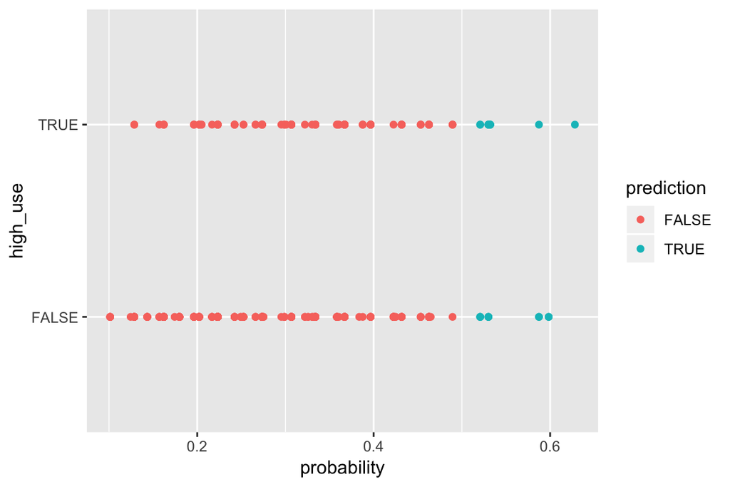

```r
g <- ggplot(joined_data, aes(x = probability, y = high_use, col = prediction))
g + geom_point()
```

```r
table(high_use = joined_data$high_use, prediction = joined_data$prediction) %>% prop.table %>% addmargins
```

```
##         prediction
## high_use      FALSE       TRUE        Sum
##    FALSE 0.67539267 0.02617801 0.70157068
##    TRUE  0.26963351 0.02879581 0.29842932
##    Sum   0.94502618 0.05497382 1.00000000
```

```r
loss_func <- function(class, prob) {
  n_wrong <- abs(class - prob) > 0.5
  mean(n_wrong)
}
loss_func(class = joined_data$high_use, prob = joined_data$probability)
```

```
## [1] 0.2958115
```

average number of incorrect predictions is 0.2958

#### 6.Perform 10-fold cross-validation on my model

```r
library(boot)
cv <- cv.glm(data = joined_data, cost = loss_func, glmfit = m, K = 10)
cv$delta[1]
```

```
## [1] 0.3115183
```

### Load and explore the Boston data

```r
chooseCRANmirror(graphics=FALSE, ind=1)
library(MASS)
str(Boston)
```

```
## 'data.frame':    506 obs. of  14 variables:
##  $ crim   : num  0.00632 0.02731 0.02729 0.03237 0.06905 ...
##  $ zn     : num  18 0 0 0 0 0 12.5 12.5 12.5 12.5 ...
##  $ indus  : num  2.31 7.07 7.07 2.18 2.18 2.18 7.87 7.87 7.87 7.87 ...
##  $ chas   : int  0 0 0 0 0 0 0 0 0 0 ...
##  $ nox    : num  0.538 0.469 0.469 0.458 0.458 0.458 0.524 0.524 0.524 0.524 ...
##  $ rm     : num  6.58 6.42 7.18 7 7.15 ...
##  $ age    : num  65.2 78.9 61.1 45.8 54.2 58.7 66.6 96.1 100 85.9 ...
##  $ dis    : num  4.09 4.97 4.97 6.06 6.06 ...
##  $ rad    : int  1 2 2 3 3 3 5 5 5 5 ...
##  $ tax    : num  296 242 242 222 222 222 311 311 311 311 ...
##  $ ptratio: num  15.3 17.8 17.8 18.7 18.7 18.7 15.2 15.2 15.2 15.2 ...
##  $ black  : num  397 397 393 395 397 ...
##  $ lstat  : num  4.98 9.14 4.03 2.94 5.33 ...
##  $ medv   : num  24 21.6 34.7 33.4 36.2 28.7 22.9 27.1 16.5 18.9 ...
```

```r
dim(Boston)
```

```
## [1] 506  14
```

The Boston data has 14 variables, 506 rows, a description of housing values in suburbs of Boston. Each variable represents the following meanings: crim, per capita crime rate by town.zn, proportion of residential land zoned for lots over 25,000 sq.ft.indus,proportion of non-retail business acres per town.chas, Charles River dummy variable (= 1 if tract bounds river; 0 otherwise).nox, nitrogen oxides concentration (parts per 10 million).rm average number of rooms per dwelling. age, proportion of owner-occupied units built prior to 1940.dis, weighted mean of distances to five Boston employment centres.rad, index of accessibility to radial highways.tax, full-value property-tax rate per $10,000.ptratio pupil-teacher ratio by town.black, 1000(Bk - 0.63)^2 where Bk is the proportion of blacks by town.lstat, lower status of the population (percent).medv,median value of owner-occupied homes in $1000s

### explore the data with plot

[figure not shown]

```r
library(dplyr)
install.packages("corrplot")
library(corrplot)
pairs(Boston)
```

```r
cor_matrix<-cor(Boston) %>% round(digits = 2)
cor_matrix
```

```
##          crim    zn indus  chas   nox    rm   age   dis   rad   tax
## crim     1.00 -0.20  0.41 -0.06  0.42 -0.22  0.35 -0.38  0.63  0.58
## zn      -0.20  1.00 -0.53 -0.04 -0.52  0.31 -0.57  0.66 -0.31 -0.31
## indus    0.41 -0.53  1.00  0.06  0.76 -0.39  0.64 -0.71  0.60  0.72
## chas    -0.06 -0.04  0.06  1.00  0.09  0.09  0.09 -0.10 -0.01 -0.04
## nox      0.42 -0.52  0.76  0.09  1.00 -0.30  0.73 -0.77  0.61  0.67
## rm      -0.22  0.31 -0.39  0.09 -0.30  1.00 -0.24  0.21 -0.21 -0.29
## age      0.35 -0.57  0.64  0.09  0.73 -0.24  1.00 -0.75  0.46  0.51
## dis     -0.38  0.66 -0.71 -0.10 -0.77  0.21 -0.75  1.00 -0.49 -0.53
## rad      0.63 -0.31  0.60 -0.01  0.61 -0.21  0.46 -0.49  1.00  0.91
## tax      0.58 -0.31  0.72 -0.04  0.67 -0.29  0.51 -0.53  0.91  1.00
## ptratio  0.29 -0.39  0.38 -0.12  0.19 -0.36  0.26 -0.23  0.46  0.46
## black   -0.39  0.18 -0.36  0.05 -0.38  0.13 -0.27  0.29 -0.44 -0.44
## lstat    0.46 -0.41  0.60 -0.05  0.59 -0.61  0.60 -0.50  0.49  0.54
## medv    -0.39  0.36 -0.48  0.18 -0.43  0.70 -0.38  0.25 -0.38 -0.47
##         ptratio black lstat  medv
## crim       0.29 -0.39  0.46 -0.39
## zn        -0.39  0.18 -0.41  0.36
## indus      0.38 -0.36  0.60 -0.48
## chas      -0.12  0.05 -0.05  0.18
## nox        0.19 -0.38  0.59 -0.43
## rm        -0.36  0.13 -0.61  0.70
## age        0.26 -0.27  0.60 -0.38
## dis       -0.23  0.29 -0.50  0.25
## rad        0.46 -0.44  0.49 -0.38
## tax        0.46 -0.44  0.54 -0.47
## ptratio    1.00 -0.18  0.37 -0.51
## black     -0.18  1.00 -0.37  0.33
## lstat      0.37 -0.37  1.00 -0.74
## medv      -0.51  0.33 -0.74  1.00
```

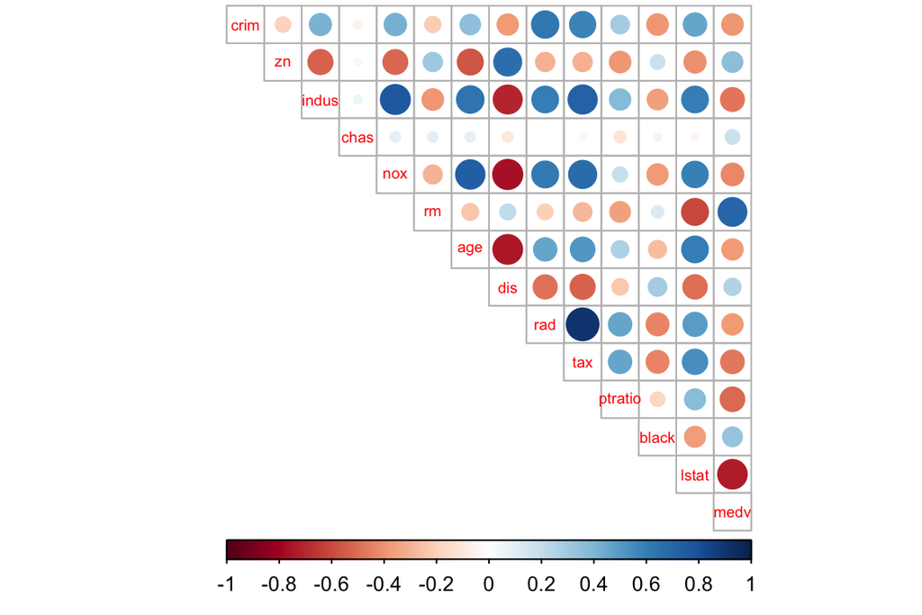

```r
corrplot(cor_matrix, method="circle", type="upper", cl.pos="b", tl.pos="d", tl.cex = 0.6)
```

As the plot shows that variables are positively and negatively correlated. For instance, variable, lower status of the population (percent) and median value of owner-occupied homes in $1000s is negatively correlated.Also, rad, index of accessibility to radial highways.and tax, full-value property-tax rate per $10,000 are positively related. Other highly correlated variables are: dis&indus; nox&age, indus&tax; rm&medv.